# Pitcher card

# Daniel Lynch IV

LHP · KC

2026 · 56 G (10 GS) · 1,300 pitches · Mar 30 – Sep 27, 2026

Independent portfolio sample by Devin Jenkinson, not affiliated with any club. Every number is computed from public Statcast data.

Three big takeaways

1Attack

The slider is the put-away pitch. Use it to finish at-bats.

32% of two-strike pitches · 28% whiffs/swing (71 swings)

It grades 100 Stuff+. Next best two-strike miss rate: the changeup at 20%.

2Avoid

Limit the 4-seam fastball. It is his most damaging pitch.

xRV/100 -1.36 shrunk (raw -3.04) · .439 xwOBAcon · 190 pitches

When behind in the count he throws it 14% of the time; the slider grades +0.86 there instead.

3Watch

After the slider, hitters chase the changeup most.

39% chased on 165 out-of-zone pitches

Fastball height splits are too thin to call (44 swings up, 79 down).

Charts

### Movement

The KC finishes 22 in from his SI, with 19 in more glove-side run.

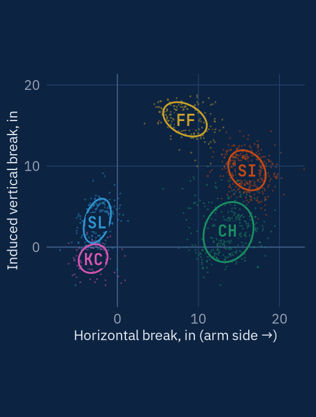

n = 1,300 pitches. Ellipses hold about 68% of each type; codes sit at the averages.

### Location by count

He throws 50% of pitches in the zone when behind and 46% when ahead.

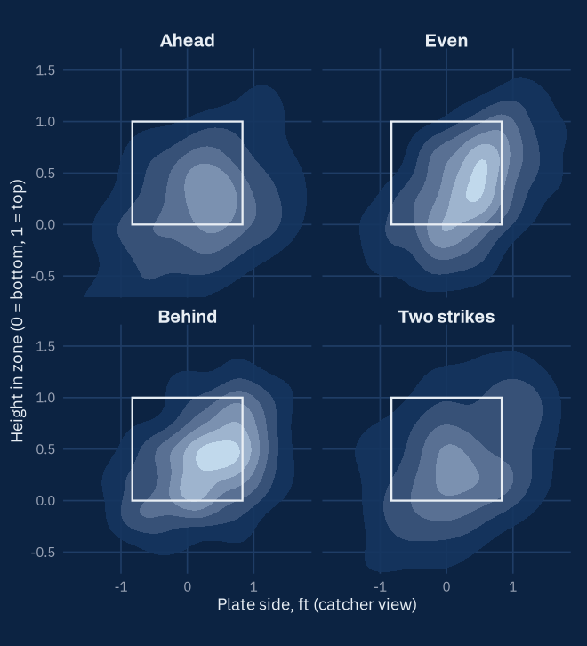

n = 1,300. Ahead 157 · even 486 · behind 317 · two strikes 340 pitches. Box = rule-book zone.

### Put-away

The SL is 32% of two-strike pitches vs 19% overall.

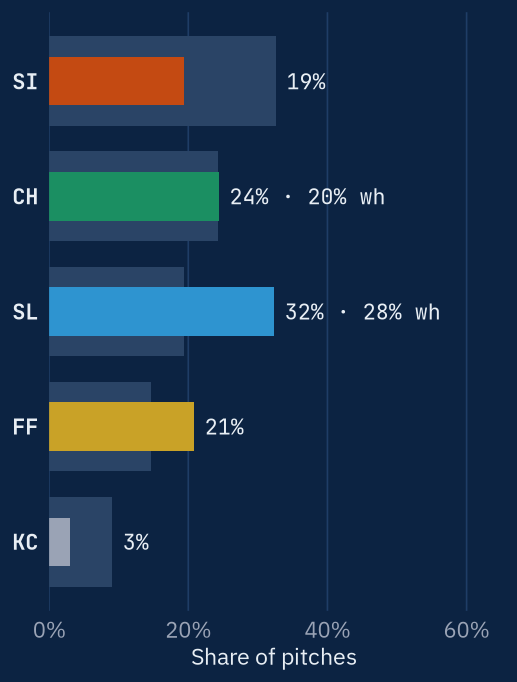

Two-strike n: SL 110, CH 83, FF 71, SI 66, KC 10. Grey bars = overall usage; wh = whiffs per swing (shown with 50+ swings).

### Arsenal

| Pitch | # | Use | Velo | IVB | HB | VAA | Whiff | Chase | xwOBAcon | xRV/100 | Stuff+ |
| --- | --- | --- | --- | --- | --- | --- | --- | --- | --- | --- | --- |
| Sinker (SI) | 424 | 33% | 93.9 | 9.5 | +16.0 | -6.1 | 14% | 28% | .329 | +0.77 | 97 |
| Changeup (CH) | 316 | 24% | 85.5 | 2.1 | +13.6 | -7.5 | 24% | 39% | .377 | -0.21 | 95 |
| Slider (SL) | 252 | 19% | 87.3 | 3.1 | -2.5 | -7.8 | 36% | 36% | .294 | +0.86 | 100 |
| 4-Seam (FF) | 190 | 15% | 94.5 | 15.7 | +8.5 | -4.9 | 15% | 17% | .439 | -1.36 | 85 |
| Knuckle Curve (KC) | 118 | 9% | 81.8 | -1.5 | -2.9 | -8.5 | 21% | 24% | .415 | -0.58 | 95 |

IVB / HB in inches (HB + = arm side). VAA in degrees at the front of the plate. xRV/100 = expected run value per 100 pitches, pitcher’s view, shrunk with a 250-pitch prior. Stuff+ = this project’s shape-only model (100 = MLB average, 10 = 1 SD).

### Vs. batter hand

| Pitch | LHH # | Use | Whiff | xwOBAcon | RHH # | Use | Whiff | xwOBAcon |
| --- | --- | --- | --- | --- | --- | --- | --- | --- |
| SI | 235 | 51% | 12% | .302 | 189 | 22% | 17% | .366 |
| CH | 16 | 4% | – | .354 | 300 | 36% | 24% | .349 |
| SL | 175 | 38% | 38% | .198 | 77 | 9% | – | .283 |
| FF | 23 | 5% | – | .400 | 167 | 20% | 13% | .415 |
| KC | 8 | 2% | – | .844 | 110 | 13% | – | .351 |

Use = share of pitches to that side. Whiff = whiffs per swing, shown with 50+ swings.